# IE 360 HW 2&3

There is my Homework 2&3. In this homework, we are using EPIAS electric consumtion data in between 2016-2020 by hourly. I believe, this homework’s main purpose is analyzing time series more deeply and making forecasts based on our analyses.

```r
setwd("/Users/bahadir/Documents/BahadirAyan")
getwd()
library(dplyr)
library(data.table)
library(readxl)
library(lubridate)
library(ggplot2)
library("xts")
library("zoo")
library("tidyverse")
library(stats)
```

I read the data from csv data.

```r
electricity_consumption<-read.csv("electricty.csv")
electricity_consumption
```

After that I adjusted data because R read electric consumption data as a factor. I convert electric consumption data to character and trimmed last 3 character of it. I did this because electric consumption data had dot and comma at the same time. In according to, convert them to number correctly I did these adjustments.

```r
electricity_consumption_2<-as.data.frame(electricity_consumption$Tüketim.Miktarı..MWh.)

names(electricity_consumption_2)[names(electricity_consumption_2)=="electricity_consumption$Tüketim.Miktarı..MWh."]<-"consumption"


electricity_consumption_2$consumption<-as.character(electricity_consumption_2$consumption)

electricity_consumption_2$consumption<-substr(electricity_consumption_2$consumption,1,nchar(electricity_consumption_2$consumption)-3)

electricity_consumption_2$consumption<-as.numeric(electricity_consumption_2$consumption)
```

I used that function to aggregate data for different periods.

```r
n.colsum = function(df, n = 24){
  aggregate(x = df, by = list(gl(ceiling(nrow(df)/n), n)[1:nrow(df)]),FUN = sum)
}
```

I created hourly electric consumption data

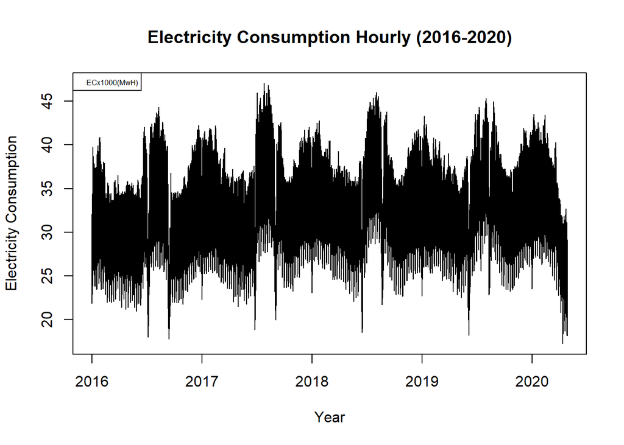

```r
electricity_consumption_ts_hourly<-ts(electricity_consumption_2,start=c(2016,1),freq=365*24)

ts.plot(electricity_consumption_ts_hourly,xlab = "Year", ylab = "Electricity Consumption",main="Electricity Consumption Hourly (2016-2020)")
legend("topleft",col="blue",legend=c("ECx1000(MwH)"),cex=0.5)
```

I created daily, weekly and monthly data by this way

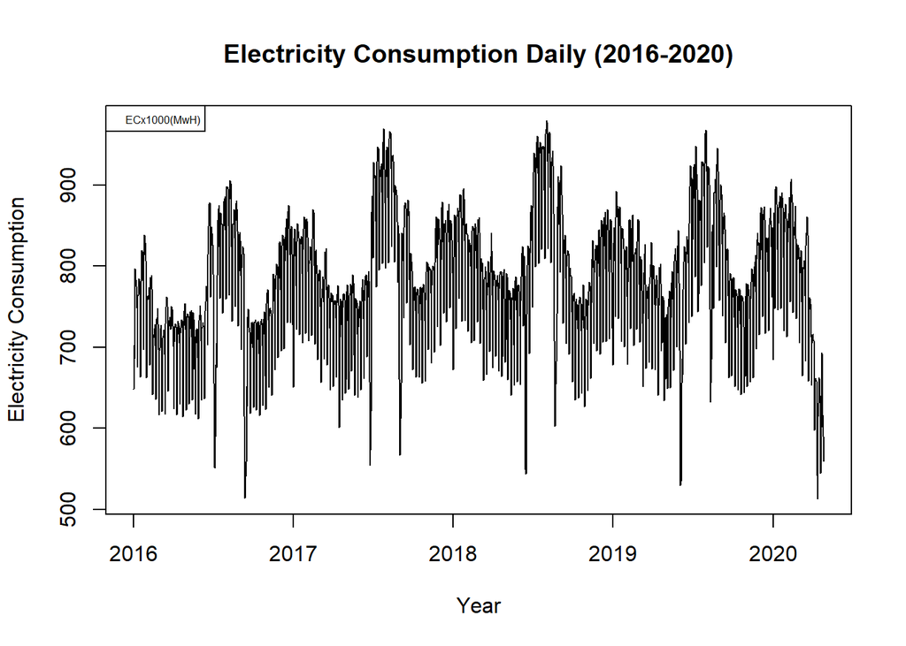

[figure not shown]

[figure not shown]

```r
ec_nothour_daily<-n.colsum(electricity_consumption_2,n=24)
ec_nothour_daily$Group.1<-NULL

electricity_consumption_ts_daily<-ts(ec_nothour_daily,start=c(2016,1),freq=365)

ts.plot(electricity_consumption_ts_daily,
        xlab = "Year",
        ylab = "Electricity Consumption",
        main="Electricity Consumption Daily (2016-2020)")
legend("topleft",col="blue",legend=c("ECx1000(MwH)"),cex=0.5)
```

I decomposed hourly data by multiplicative and additive types to decide which method to use. There is no significant difference multiplicative decomposition and additive decompostion. I decided to use multiplicative type.

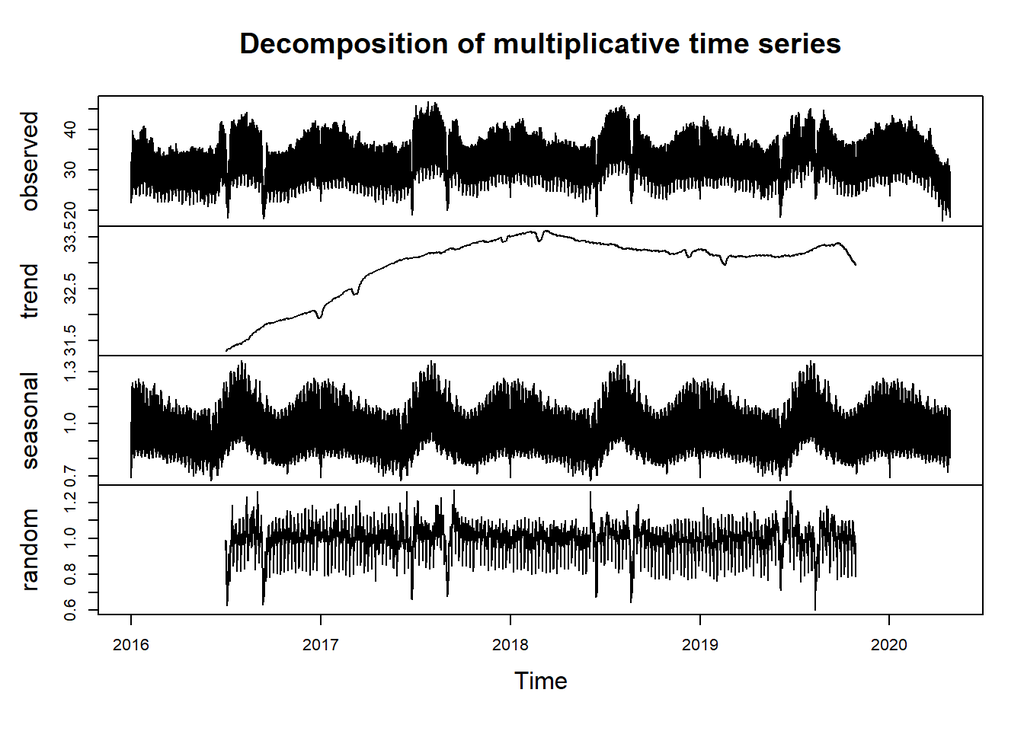

```r
##Decompose Hourly Data
electricity_consumption_ts_hourly
is.ts(electricity_consumption_ts_hourly)
#Multiplicative
ec_hourly_multip<-decompose(electricity_consumption_ts_hourly,type="multiplicative")

ec_hourly_multip

plot(ec_hourly_multip)
```

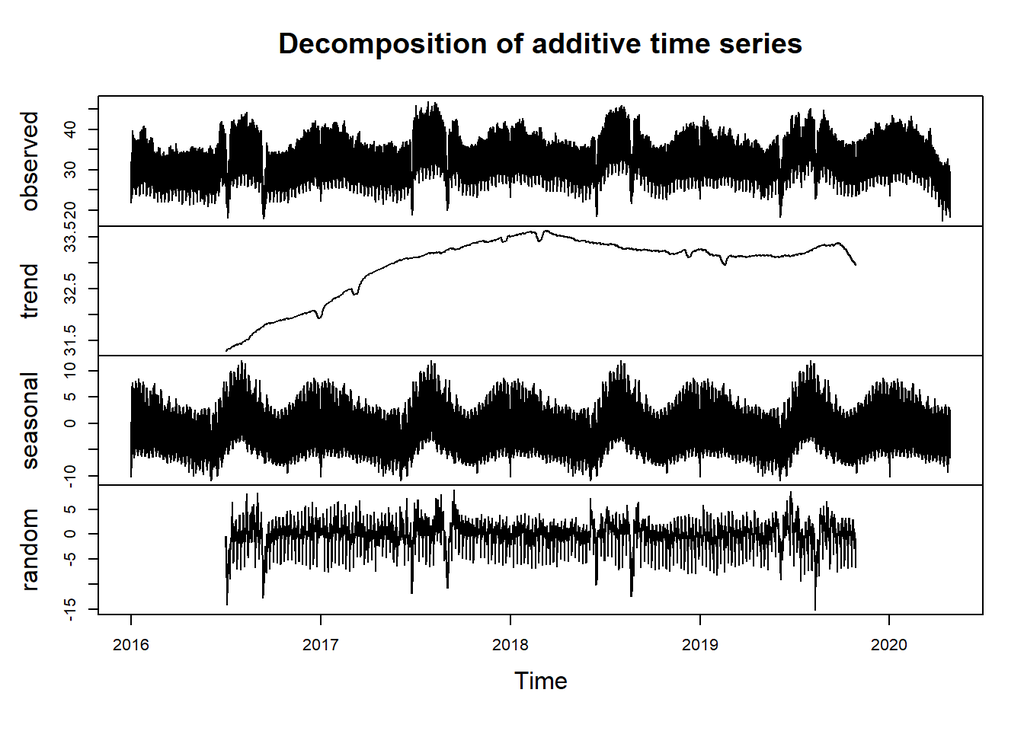

```r
#Additive

electricity_consumption_ts_hourly_log<-log(electricity_consumption_ts_hourly)

ec_hourly_additive<-decompose(electricity_consumption_ts_hourly,type="additive")

ec_hourly_additive

plot(ec_hourly_additive)
```

As seen on the graph, hourly data has increasing trend in between 2016-2018. In contrast, has steady but low decrease in between 2018-2020. Additionally, hourly data has seasonality and it can be seen on the graph.

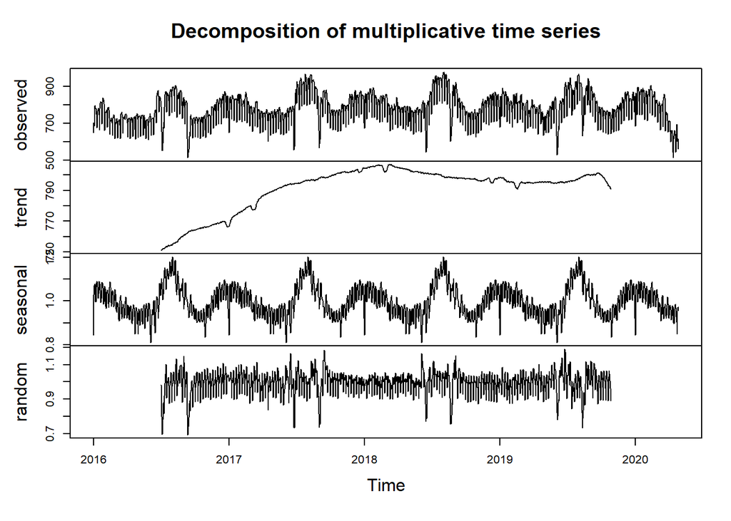

```r
ec_daily_multip<-decompose(electricity_consumption_ts_daily,type="multiplicative")

ec_daily_multip

plot(ec_daily_multip)
```

This graph represents decomposition of daily electric consumtion data by multiplicative type.

As seen on the graph, daily data has increasing trend in between 2016-2018. In contrast, has steady but low decrease in between 2018-2020. Additionally, daily data has strong seasonality can be seen on the graph.

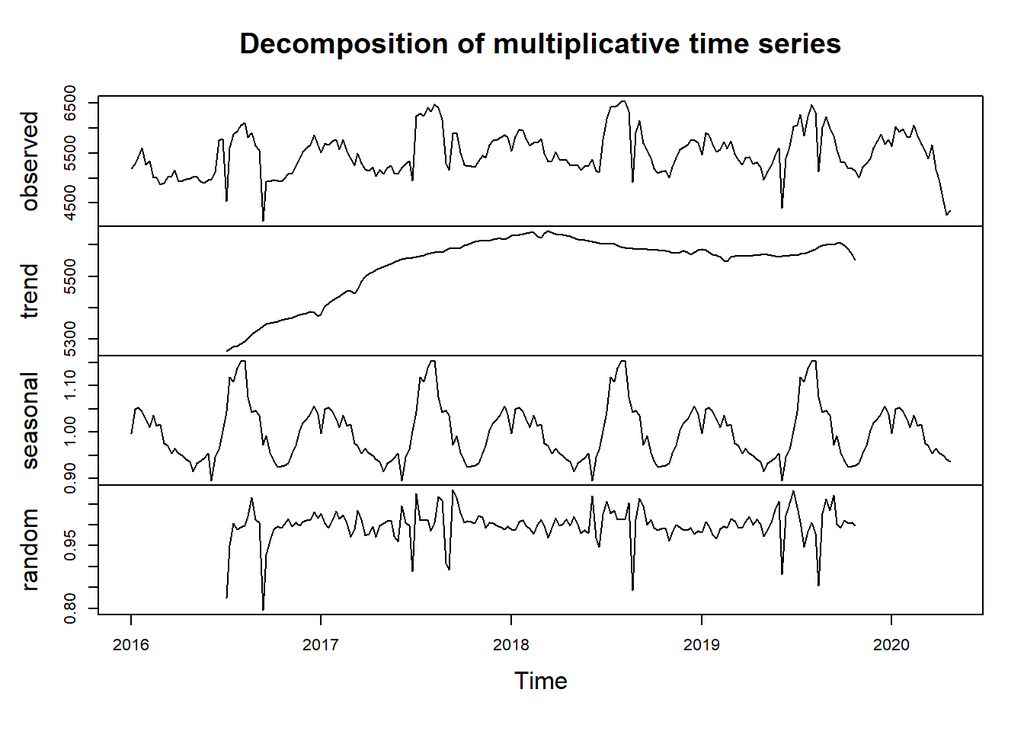

This graph represents decomposition of weekly electric consumtion data by multiplicative type.

As seen on the graph, weekly data has increasing trend in between 2016-2018. In contrast, has steady but low decrease in between 2018-2020. Additionally, weekly data has strong seasonality can be seen on the graph.

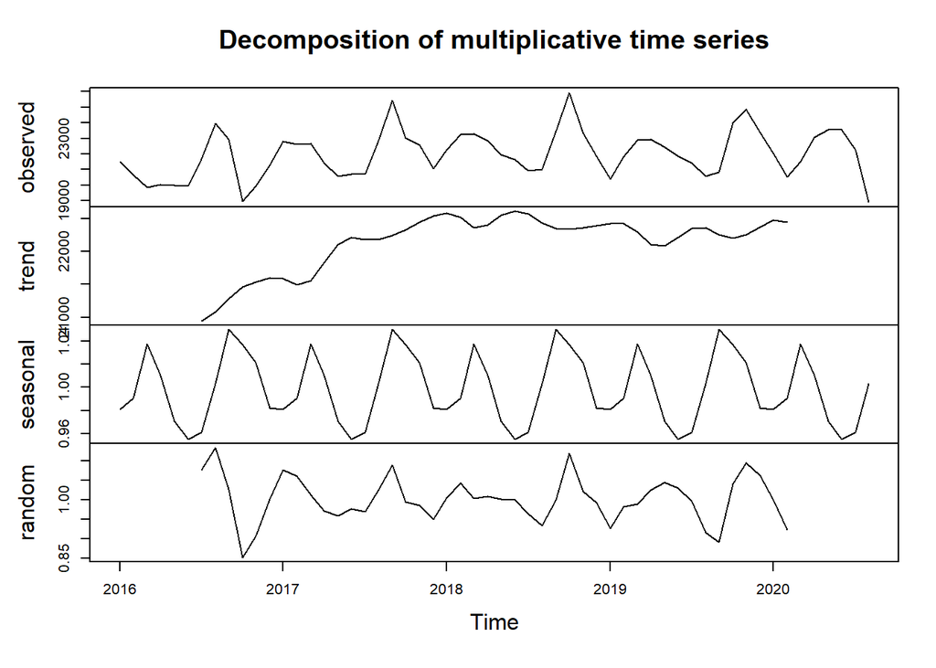

This graph represents decomposition of monthly electric consumtion data by multiplicative type.

As seen on the graph, monthly data has increasing trend in earlier years.  
After that, trend becomes steady. Additionally, monthly data has strong seasonality can be seen on graph

We can see there are different seasonalities on all decomposition graphs. In order to build successfull model, I will try try to remove those seasonalities in electric consumtpion data.

I looked auto correlation graphs of series to identify patterns.

Firstly, I looked autocorrelation of time series of hourly electric consumption data.

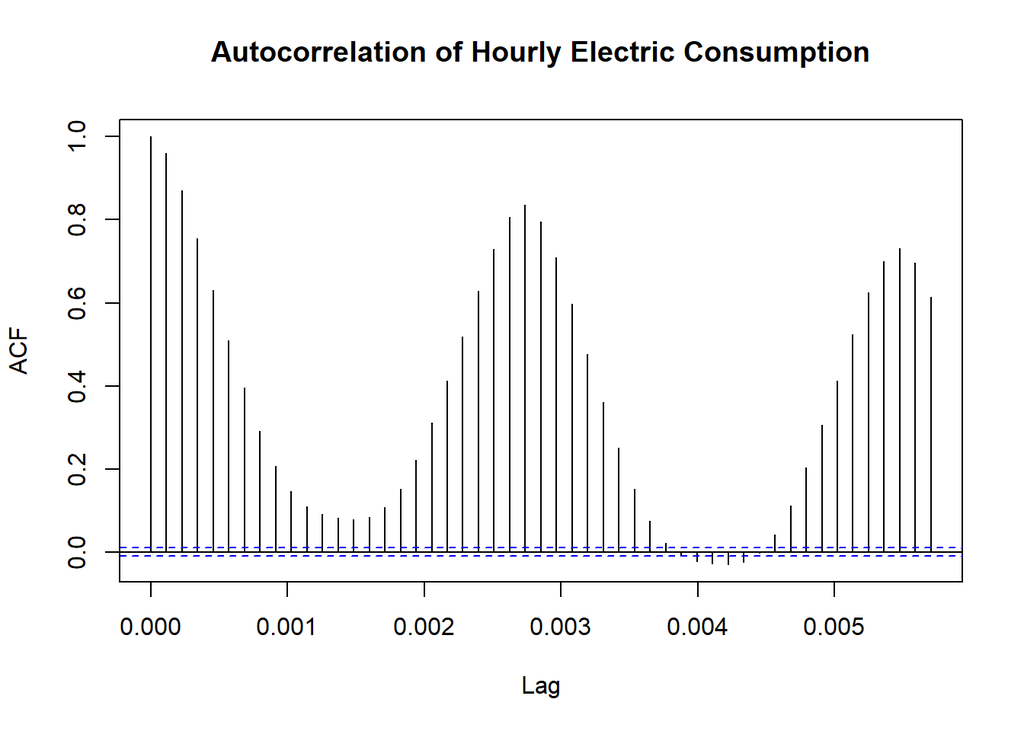

```r
acf(electricity_consumption_ts_hourly,lag.max = 50,main="Autocorrelation of Hourly Electric Consumption")
```

Hourly data has strong correlation on lag=24 and that correlation repeats every k*24 lag. Therefore, I believe there is a pattern. Additionally, it makes sense a lot because lag=24 represents 1 day pattern.

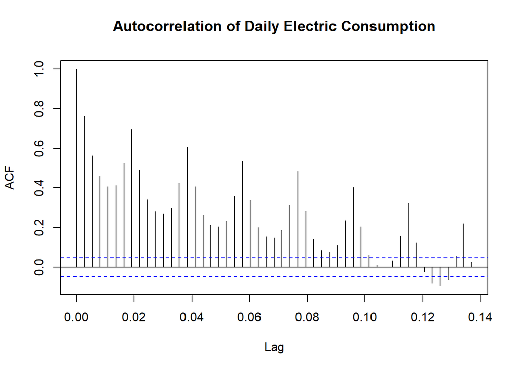

```r
acf(electricity_consumption_ts_daily,lag.max = 50,main="Autocorrelation of Daily Electric Consumption")
```

Daily data has strong correlation on lag=7 and that correlation repeats every k*7 lag. Therefore I believe say there is a pattern. Additionally, it makes sense a lot because lag=7 represents 1 week pattern.

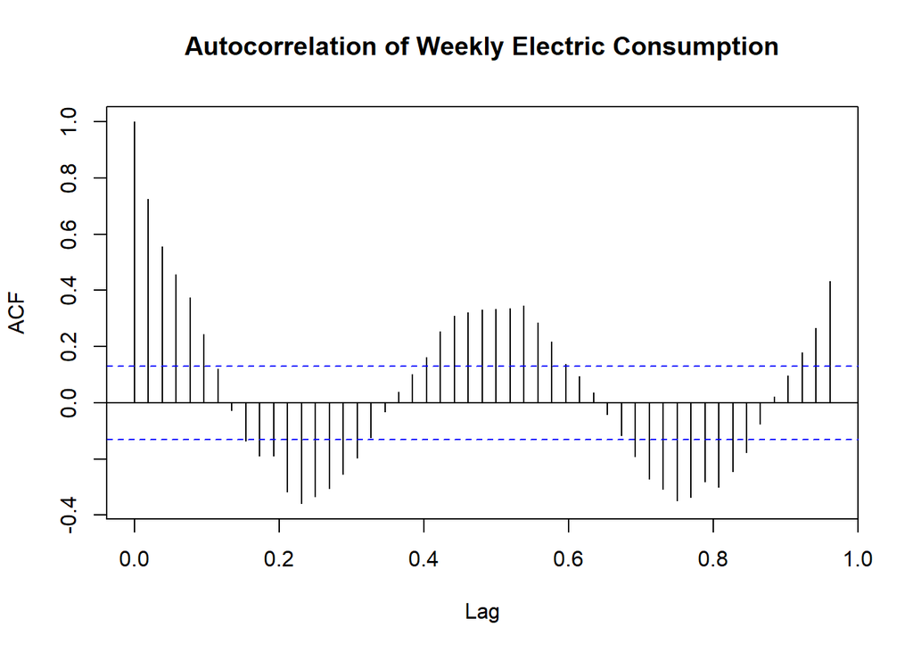

```r
acf(electricity_consumption_ts_weekly,lag.max = 50,main="Autocorrelation of Weekly Electric Consumption")
```

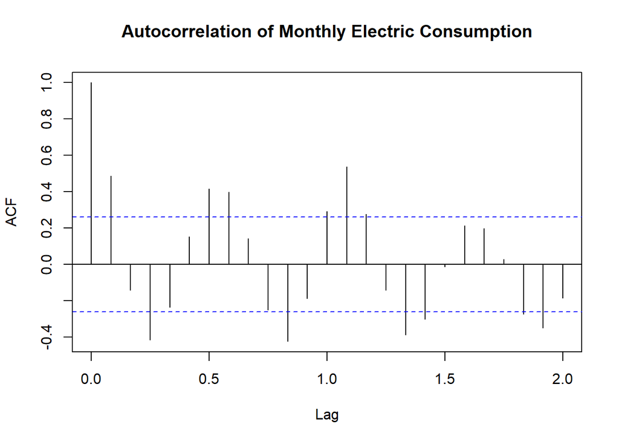

```r
acf(electricity_consumption_ts_monthly,lag.max = 24,main="Autocorrelation of Monthly Electric Consumption")
```

Monthly data has moderate correlation on lag =3 and lag= 6. We can say there is pattern. Additionally, it makes sense because we can say quartlery electric consumption has negative correlation but in 2 quarters electric consumption has positive correlation.

I decided to work on hourly data and I know hourly data has seasonality for 24 hours. Additionally, daily data has seasonality for 7 days. I can conclude that there is 168 hour pattern on hourly data. To build my model, I need to remove that seasonality and trend. I will start by deseasonalizin the hourly time series.

I deseasonalized hourly data by this way and I put raw data plot and deaseasonalized data plot to see changes.

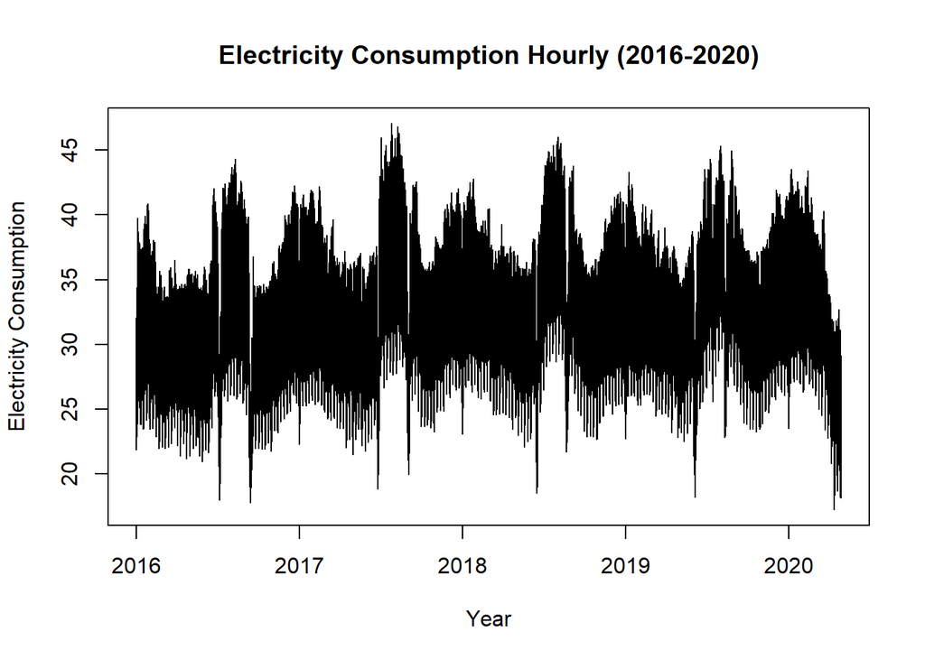

```r
#Deseasonalize hourly data
deseasonalized_ec_hourly<-electricity_consumption_ts_hourly/ec_hourly_multip$seasonal

#Raw Hourly Data
ts.plot(electricity_consumption_ts_hourly,xlab = "Year", ylab = "Electricity Consumption",main="Electricity Consumption Hourly (2016-2020)")
```

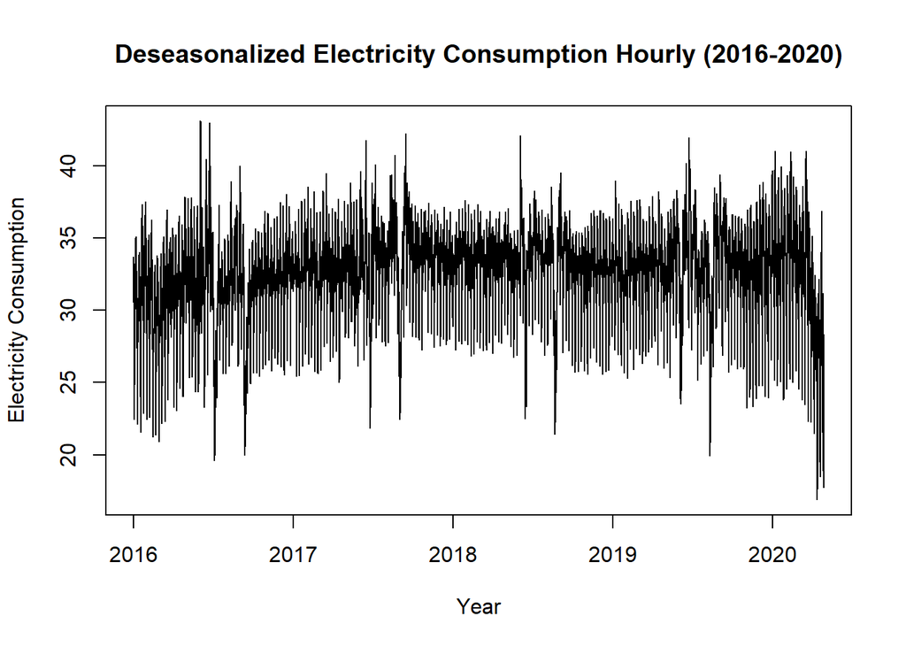

```r
#Deseasonalized hourly data
ts.plot(deseasonalized_ec_hourly,xlab = "Year", ylab = "Electricity Consumption",main="Deseasonalized Electricity Consumption Hourly (2016-2020)")
```

After the deseasonalization process, I trended the data. I used similar approach to remove trends. Again, I put detrended data plot to see changes.

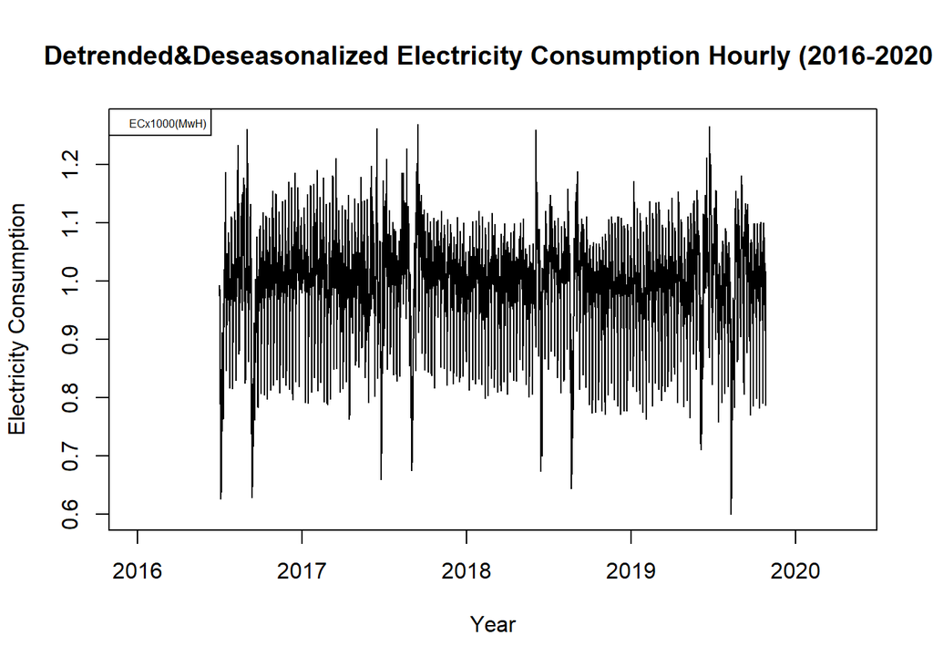

```r
detrend_ec_hourly<-deseasonalized_ec_hourly/ec_hourly_multip$trend

ts.plot(detrend_ec_hourly,xlab = "Year", ylab = "Electricity Consumption",main="Detrended&Deseasonalized Electricity Consumption Hourly (2016-2020)")
legend("topleft",col="blue",legend=c("ECx1000(MwH)"),cex=0.5)
```

Afther these operation. I started to build a model. Firtly, I started with AR Model. I changed p paramater to obtain better model and I decided on 7 value because 7 value generated minimum AIC value

```r
ARmodel_hourly<-arima(detrend_ec_hourly,order=c(7,0,0))
print(ARmodel_hourly)
```

```
##
## Call:
## arima(x = detrend_ec_hourly, order = c(7, 0, 0))
##
## Coefficients:
##          ar1      ar2     ar3      ar4     ar5     ar6      ar7  intercept
##       1.4987  -0.5217  0.0186  -0.1941  0.2218  0.0457  -0.0933     0.9991
## s.e.  0.0058   0.0105  0.0109   0.0108  0.0109  0.0106   0.0058     0.0028
##
## sigma^2 estimated as 0.0001327:  log likelihood = 88560.4,  aic = -177102.8
```

```r
AIC(ARmodel_hourly)
```

```
## [1] -177102.8
```

After that, I built MA model. Again, I changed q paramater to obtain better model and I decided on 7 value because 7 value generated minimum AIC value

```r
MAmodel_hourly<-arima(detrend_ec_hourly,order=c(0,0,7))
print(MAmodel_hourly)
```

```
##
## Call:
## arima(x = detrend_ec_hourly, order = c(0, 0, 7))
##
## Coefficients:
##          ma1     ma2     ma3     ma4     ma5     ma6     ma7  intercept
##       1.6886  2.1056  2.2411  1.8980  1.3096  0.7407  0.2579     0.9991
## s.e.  0.0058  0.0108  0.0141  0.0147  0.0123  0.0087  0.0051     0.0009
##
## sigma^2 estimated as 0.0001707:  log likelihood = 84898.88,  aic = -169779.8
```

```r
AIC(MAmodel_hourly)
```

```
## [1] -169779.8
```

AR Model has better AIC value than MA model. Therefore, I used AR model to make my predictions. I put detrended & deseasonalized hourly electric consumption graph to show how my model fit on the data.

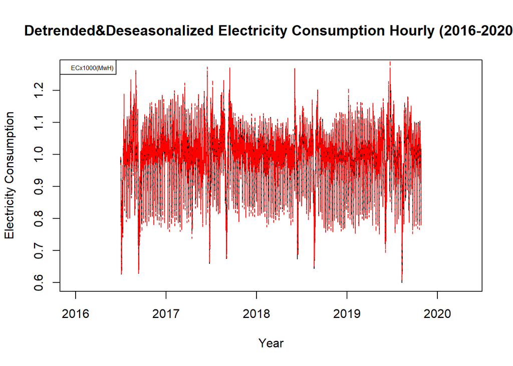

```r
ARmodel_hourly_fitted<- detrend_ec_hourly-residuals(ARmodel_hourly)

ts.plot(detrend_ec_hourly,xlab = "Year", ylab = "Electricity Consumption",main="Detrended&Deseasonalized Electricity Consumption Hourly (2016-2020)")
legend("topleft",col="blue",legend=c("ECx1000(MwH)"),cex=0.5)

points(ARmodel_hourly_fitted, type="l",col=2, lty=2)
```

Before make any predictions, I calculated average of seasonal and trend components because when I detrend the data, trending operation trims first and last trend components

```r
seasonalavg<-mean(ec_hourly_multip$seasonal)
seasonalavg

na.omitted<-na.omit(ec_hourly_multip$trend)
trendavg<-mean(na.omitted)
trendavg
```

After that numerical adjustments, I made my predictions and I adjusted them by multiplying with seasonal and trend data. I also put my predictions by multiplying with standard error in order to show max and min points of my prediction. Lastly, I put my prediction as a point on the graph.

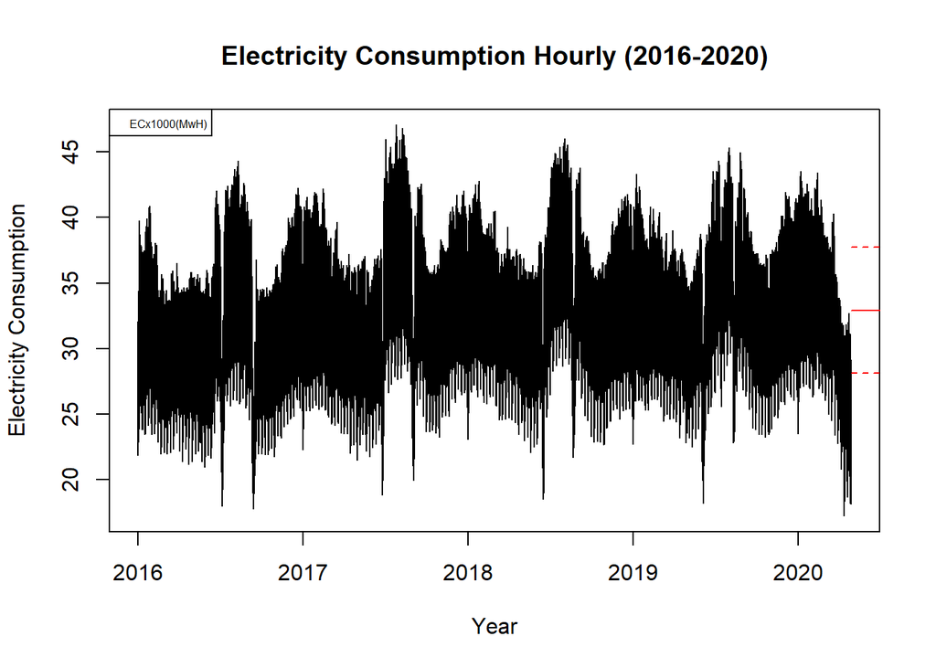

```r
ts.plot(electricity_consumption_ts_hourly,xlab = "Year", ylab = "Electricity Consumption",main="Electricity Consumption Hourly (2016-2020)")
legend("topleft",col="blue",legend=c("ECx1000(MwH)"),cex=0.5)

ARmodel_hourly_forecast<-predict(ARmodel_hourly,n.ahead=2400)$pred

ARmodel_hourly_forecast_se<-predict(ARmodel_hourly,n.ahead=2400)$se

ARmodel_hourly_forecast_new<-ARmodel_hourly_forecast*seasonalavg*trendavg
ARmodel_hourly_forecast_new

ARmodel_hourly_forecast_se_new<-ARmodel_hourly_forecast_se*seasonalavg*trendavg
ARmodel_hourly_forecast_se_new

points(ARmodel_hourly_forecast_new,type="l",col=2)
points(ARmodel_hourly_forecast_new - 1.96*ARmodel_hourly_forecast_se_new, type = "l", col = 2, lty = 2)
points(ARmodel_hourly_forecast_new + 1.96*ARmodel_hourly_forecast_se_new, type = "l", col = 2, lty = 2)
```

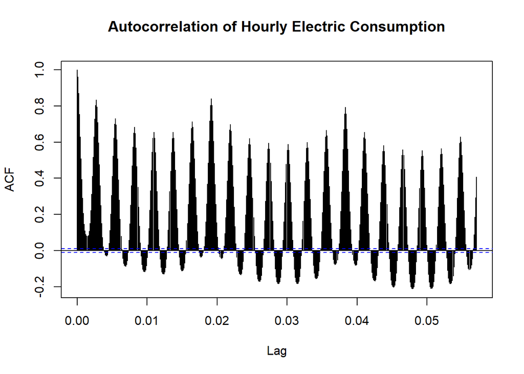

```r
acf(electricity_consumption_ts_hourly,lag.max = 500,main="Autocorrelation of Hourly Electric Consumption")
```

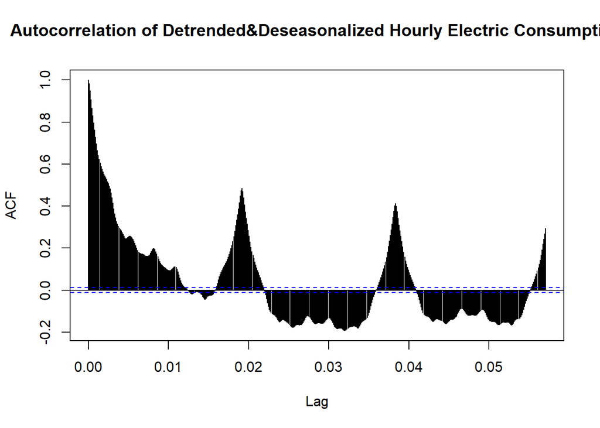

```r
acf(detrend_ec_hourly,na.action=na.omit,lag.max = 500,main="Autocorrelation of Detrended&Deseasonalized Hourly Electric Consumption")
```

As seen on the graphs, I removed 24 hours seasonality but weekly seasonality effect remains on hourly data.

You can reach my script file form here: https://github.com/BU-IE-360/spring20-BahadirAyan/blob/master/files/IE360Homework2%263.R